# Indel Signature InsDel19b

# InsDel19b

(corresponds to 83-type signature C_ID19)

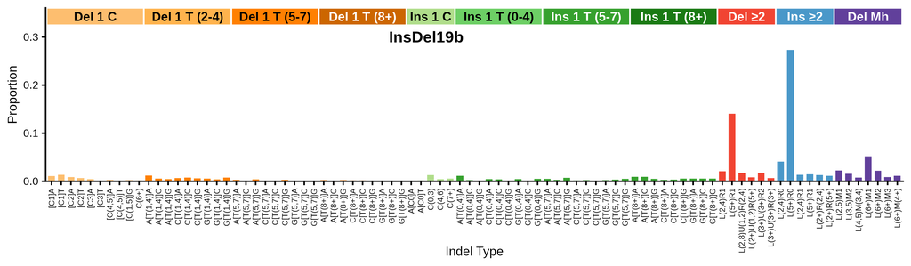

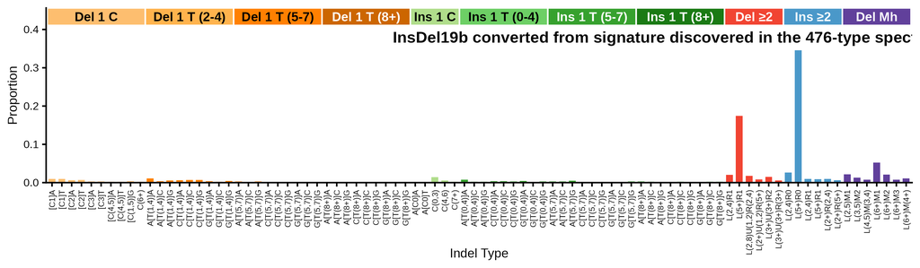

89-type spectrum of the linking tumor CPCT02050192T | cosine similarity to InsDel19b: 0.9922

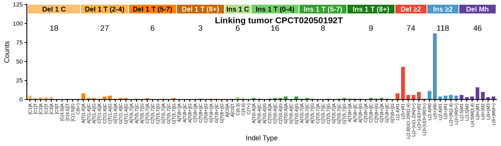

**Click to view decomposition of the linking tumor spectrum**

Partial mutation signature of CPCT02050192T due to InsDel19b

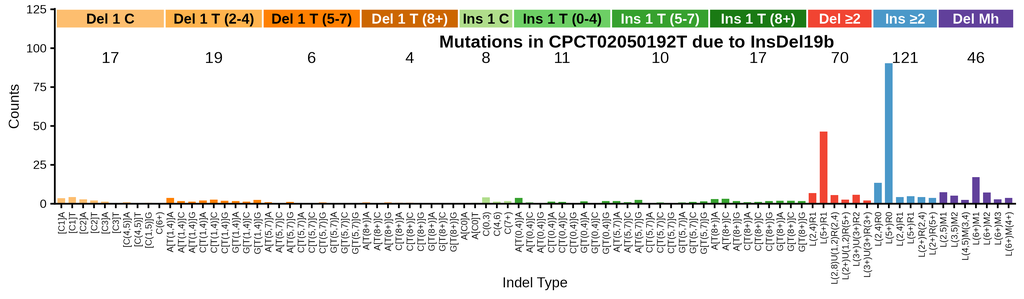

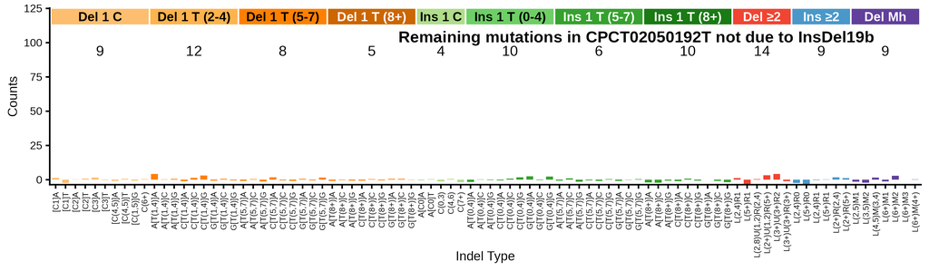

Max neg fraction (maximum allowed negative residual count as fraction of total): 0.15  
N subtract (mutation count assigned to signature): 331.0  
N residual (mutation count in residual “partial spectrum”): 0.0  
Total negative (sum of negative residual mutation counts): 49.4  
N negative channels (number of channels with negative residual): 46  
P(≥ total negative) (Monte Carlo estimated probability that negative-binomial-sampled spectra from the signature contributing N subtract mutations would produce a total negative count >= the observed Total negative; higher number means not surprising): 0.885

**Per-channel residual breakdown**

| Channel | Spectrum | Sig_Count | Residual | Sig_Prop |
| --- | --- | --- | --- | --- |
| [Del(C):R1]A | 5 | 3.6 | 1.4 | 0.01102 |
| [Del(C):R1]T | 2 | 4.4 | -2.4 | 0.01317 |
| [Del(C):R2]A | 3 | 2.8 | 0.2 | 0.00855 |
| [Del(C):R2]T | 3 | 2.1 | 0.9 | 0.00633 |
| [Del(C):R3]A | 3 | 1.4 | 1.6 | 0.00423 |
| [Del(C):R3]T | 0 | 0.4 | -0.4 | 0.00113 |
| [Del(C):R(4,5)]A | 0 | 1.0 | -1 | 0.00293 |
| [Del(C):R(4,5)]T | 1 | 0.5 | 0.5 | 0.00138 |
| [Del(C):R(1,5)]G | 0 | 0.7 | -0.7 | 0.00214 |
| Del(C):R(6,9) | 1 | 0.5 | 0.5 | 0.00162 |
| A[Del(T):R(1,4)]A | 8 | 3.8 | 4.2 | 0.01159 |
| A[Del(T):R(1,4)]C | 2 | 1.8 | 0.2 | 0.00530 |
| A[Del(T):R(1,4)]G | 2 | 1.4 | 0.6 | 0.00426 |
| C[Del(T):R(1,4)]A | 1 | 2.1 | -1.1 | 0.00643 |
| C[Del(T):R(1,4)]C | 4 | 2.6 | 1.4 | 0.00788 |
| C[Del(T):R(1,4)]G | 5 | 2.0 | 3 | 0.00602 |
| G[Del(T):R(1,4)]A | 1 | 1.8 | -0.8 | 0.00536 |
| G[Del(T):R(1,4)]C | 2 | 1.3 | 0.7 | 0.00408 |
| G[Del(T):R(1,4)]G | 2 | 2.5 | -0.5 | 0.00747 |
| A[Del(T):R(5,7)]A | 0 | 1.0 | -1 | 0.00292 |
| A[Del(T):R(5,7)]C | 1 | 0.5 | 0.5 | 0.00156 |
| A[Del(T):R(5,7)]G | 0 | 1.2 | -1.2 | 0.00374 |
| C[Del(T):R(5,7)]A | 2 | 0.3 | 1.7 | 0.00096 |
| C[Del(T):R(5,7)]C | 0 | 0.5 | -0.5 | 0.00138 |
| C[Del(T):R(5,7)]G | 0 | 0.9 | -0.9 | 0.00267 |
| G[Del(T):R(5,7)]A | 1 | 0.4 | 0.6 | 0.00117 |
| G[Del(T):R(5,7)]C | 0 | 0.5 | -0.5 | 0.00144 |
| G[Del(T):R(5,7)]G | 2 | 0.5 | 1.5 | 0.00136 |
| A[Del(T):R(8,)]A | 0 | 0.8 | -0.8 | 0.00246 |
| A[Del(T):R(8,)]C | 0 | 0.4 | -0.4 | 0.00113 |

[output cut: 59 more lines]

## 476-type representations corresponding to InsDel19b

Extracted 476-type signature corresponding to InsDel19b

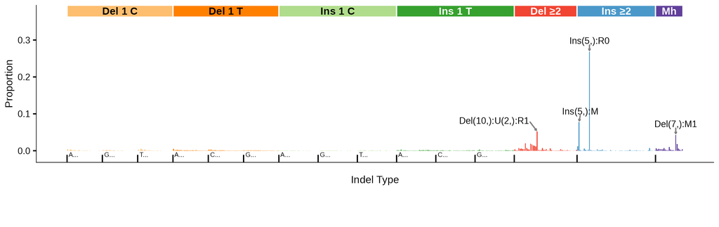

476-type spectrum of the linking tumor CPCT02050192T; cosine similarity to the extracted 476-type signature is 0.9699

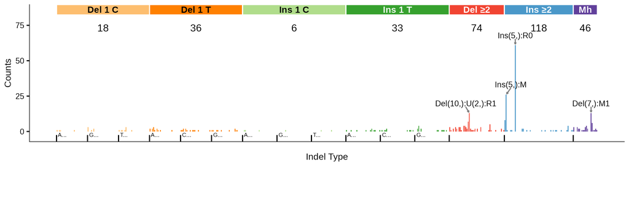

476-type spectrum of best 476-type matching tumor CPCT02340081T; cosine similarity to the extracted 476-type signature is 0.9868

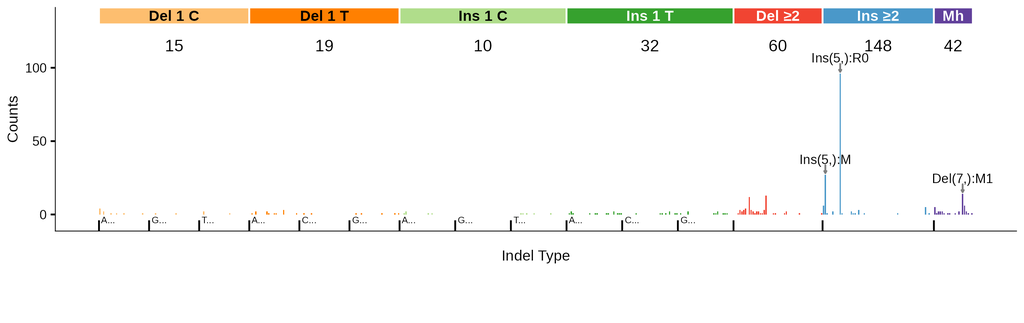

## 83-type signature corresponding to InsDel19b (C_ID19)

**Note**

The 476-type InsDel19b extraction collapses to 83-type signature close to C_ID19, with the addition of a small proportion of singe-T deletions in the context long poly-T contexts.

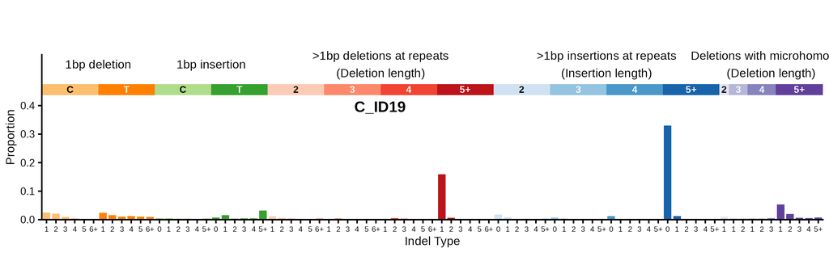

83-type signature converted from signature discovered in the 476-type spectra (using bipartite matching optimization) | cosine similarity to C_ID19: 0.9984

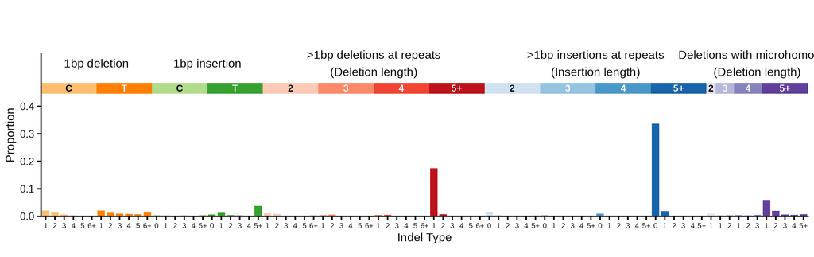

**Click to see flow diagrams: 476-type to 83-type collapse**

These Sankey diagrams show how the 476-type mutation categories are redistributed to 83-type categories using bipartite matching. We only show the diagrams for insertions or deletions of > 1 base because it is for these indels that 476-type categories map to > 1 83-type category.

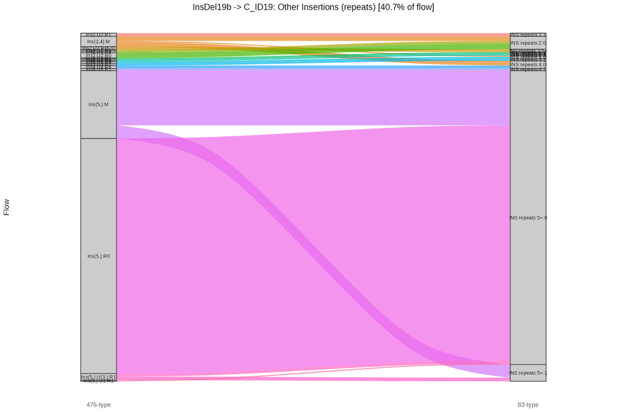

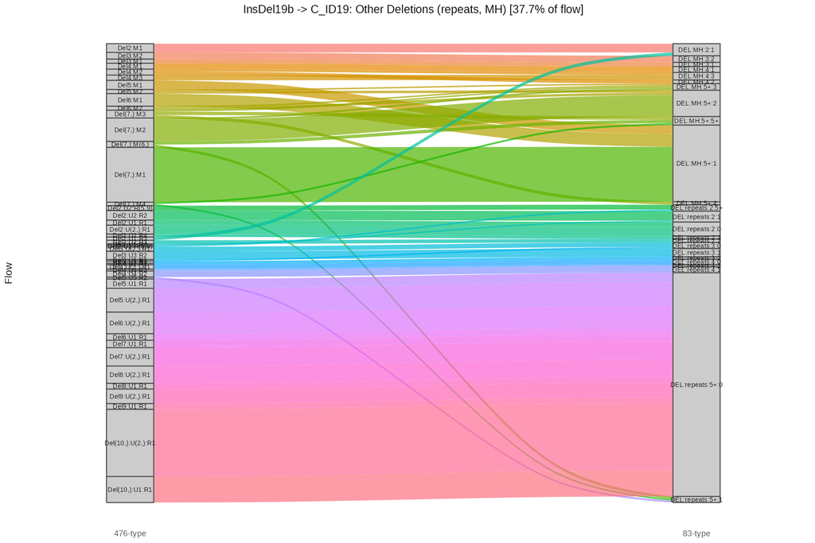

83-type spectrum of the linking tumor CPCT02050192T | cosine similarity to C_ID19: 0.9856

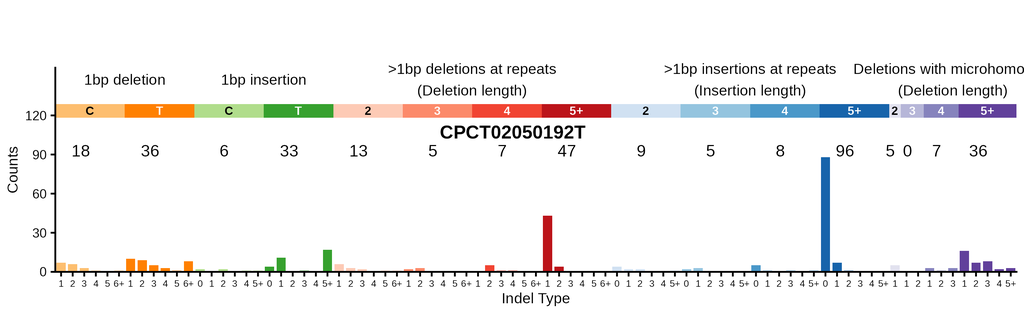

83-type spectrum of best 83-type matching tumor CPCT02080139T | cosine similarity to C_ID19: 0.9895

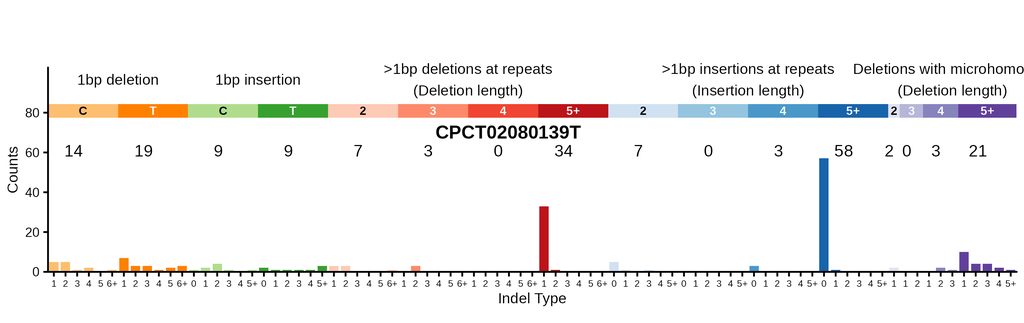